# Cartographie de la malnutrition au Cameroun

Guide pratique avec ggplot2 et plotly

Auteur·rice

kevin yimga

Date de publication

10 mars 2026

## 1 Introduction

Ce document est un **guide pratique** pour produire des cartes de malnutrition au Cameroun en R. Il couvre deux approches complémentaires :

- **ggplot2** : cartes statiques de haute qualité, exportables en image (PNG, PDF)
- **plotly** : cartes interactives avec infobulles au survol, idéales pour les rapports HTML

Les données utilisées proviennent d’une enquête nutritionnelle menée dans trois régions du Cameroun : **Adamaoua**, **Nord** et **Extrême-Nord**. Les principaux indicateurs cartographiés sont :

| Indicateur | Définition |
| --- | --- |
| **GAM** | Malnutrition aiguë globale (WHZ < −2 ou œdème) |
| **SAM** | Malnutrition aiguë sévère (WHZ < −3 ou œdème) |
| **MAM** | Malnutrition aiguë modérée (−3 ≤ WHZ < −2) |
| **Stunting** | Retard de croissance (HAZ < −2) |

**AstucePrérequis**

Assurez-vous d’avoir installé les packages suivants avant d’exécuter ce document :

```r
install.packages(c("sf", "dplyr", "ggplot2", "plotly", "knitr"))
```

Une **connexion internet** est nécessaire pour télécharger le fond de carte officiel du Cameroun (GADM).

## 2 Chargement des packages et des données

### 2.1 Packages

```r
library(sf)       # Lecture et manipulation des shapefiles (objets spatiaux)
library(dplyr)    # Manipulation des données (group_by, summarise, left_join…)
library(ggplot2)  # Cartes et graphiques statiques
library(plotly)   # Cartes interactives
library(knitr)    # Mise en forme des tableaux
```

### 2.2 Palette de couleurs OMS

L’OMS et ses partenaires (UNICEF, PAM) utilisent une palette standardisée pour la cartographie nutritionnelle, fondée sur quatre niveaux de sévérité. Ces couleurs sont alignées avec le cadre **IPC** (*Integrated Food Security Phase Classification*).

```r
# ── Couleurs de référence OMS / IPC ──────────────────────────────────────────
vert_oms        <- "#4dac26"  # Acceptable  (< 5 % GAM)
jaune_oms       <- "#f9c734"  # Alerte      (5 – 9,9 %)
orange_oms      <- "#e88400"  # Sérieux     (10 – 14,9 %)
rouge_oms       <- "#c9161d"  # Critique    (>= 15 %)
rouge_fonce_oms <- "#640000"  # Urgence max (>= 30 % / SAM élevé)

# ── Palettes par indicateur ───────────────────────────────────────────────────
pal_gam      <- c(vert_oms, jaune_oms, orange_oms, rouge_oms, rouge_fonce_oms)
pal_sam      <- c(jaune_oms, orange_oms, rouge_oms, rouge_fonce_oms)
pal_mam      <- c(vert_oms, jaune_oms, orange_oms)
pal_stunting <- c(vert_oms, jaune_oms, orange_oms, rouge_oms)

# ── Couleurs pour les statuts individuels (points GPS) ───────────────────────
couleurs_statut <- c(
  "Normal" = vert_oms,
  "MAM"    = orange_oms,
  "SAM"    = rouge_oms
)
```

**NoteRéférence des seuils OMS pour la GAM**

| Couleur | Niveau | Prévalence GAM |
| --- | --- | --- |
| Vert | Acceptable | < 5 % |
| Jaune | Alerte | 5 – 9,9 % |
| Orange | Sérieux | 10 – 14,9 % |
| Rouge | Critique | >= 15 % |
| Rouge foncé | Urgence maximale | >= 30 % |

*Source : WHO, UNICEF, WFP — SMART methodology*

### 2.3 Données

```r
df_map <- read.csv("data/donnees_malnutrition.csv", encoding = "UTF-8")
```

Les colonnes utilisées dans ce document sont les suivantes :

- **Localisation** : `region`, `district`, `village`
- **Coordonnées GPS** : `gps_latitude`, `gps_longitude`
- **Indicateurs binaires** : `GAM`, `SAM`, `MAM`, `Stunting` (1 = cas, 0 = non)
- **Statut agrégé** : `nutr_cat` — valeurs : `"SAM"`, `"MAM"`, `"Normal"`
- **Scores continus** : `whz_score`, `muac_mm`

## 3 Préparation des données

### 3.1 Calcul des prévalences par région

Pour la carte choroplèthe, nous avons besoin d’**un indicateur résumé par région**. Nous calculons le pourcentage d’enfants atteints de GAM, SAM, MAM et de retard de croissance.

```r
# mean() sur une colonne binaire (0/1) donne directement la proportion → x 100 pour le %
donnees_region <- df_map |>
  group_by(region) |>
  summarise(
    n_enfants    = n(),
    GAM_pct      = mean(GAM,      na.rm = TRUE) * 100,
    SAM_pct      = mean(SAM,      na.rm = TRUE) * 100,
    MAM_pct      = mean(MAM,      na.rm = TRUE) * 100,
    Stunting_pct = mean(Stunting, na.rm = TRUE) * 100,
    .groups = "drop"
  )

donnees_region
```

```
# A tibble: 3 × 6
  region       n_enfants GAM_pct SAM_pct MAM_pct Stunting_pct
  <chr>            <int>   <dbl>   <dbl>   <dbl>        <dbl>
1 Adamaoua            99    70.7    61.6    9.09         40.4
2 Extrême-Nord       107    74.8    65.4    9.35         37.4
3 Nord                94    73.4    63.8    9.57         37.2
```

Les prévalences de GAM dépassent **70 %** dans les trois régions enquêtées, ce qui reflète une situation nutritionnelle critique.

## 4 Fond de carte du Cameroun

### 4.1 Téléchargement depuis GADM

**GADM** (*Global Administrative Areas*) fournit des shapefiles officiels pour tous les pays du monde. Nous utilisons le **niveau 1** (régions administratives), qui correspond aux 10 régions du Cameroun.

```r
url_gadm <- "https://geodata.ucdavis.edu/gadm/gadm4.1/json/gadm41_CMR_1.json"

# st_read() lit un fichier spatial (local ou en ligne)
cameroun_sf <- st_read(url_gadm, quiet = TRUE) |>
  rename(region = NAME_1)

cameroun_sf |> select(region) |> st_drop_geometry()
```

```
         region
1      Adamaoua
2        Centre
3           Est
4  Extrême-Nord
5      Littoral
6          Nord
7    Nord-Ouest
8         Ouest
9           Sud
10    Sud-Ouest
```

**AstuceSauvegarder localement pour éviter le téléchargement répété**

```r
# Sauvegarder une fois
st_write(cameroun_sf, "data/cameroun_regions.gpkg")

# Recharger ensuite sans internet
cameroun_sf <- st_read("data/cameroun_regions.gpkg", quiet = TRUE)
```

### 4.2 Jointure shapefile avec les données de malnutrition

Nous utilisons `left_join()` pour attacher nos statistiques régionales au shapefile. Les régions **non enquêtées** auront des `NA` et seront affichées en gris sur les cartes.

```r
# left_join conserve TOUTES les régions du shapefile (y compris celles sans données)
carte_sf <- cameroun_sf |>
  left_join(donnees_region, by = "region")

carte_sf |> select(region, GAM_pct) |> st_drop_geometry()
```

```
         region  GAM_pct
1      Adamaoua 70.70707
2        Centre       NA
3           Est       NA
4  Extrême-Nord 74.76636
5      Littoral       NA
6          Nord 73.40426
7    Nord-Ouest       NA
8         Ouest       NA
9           Sud       NA
10    Sud-Ouest       NA
```

## 5 Cartes statiques avec ggplot2

### 5.1 Principe de `geom_sf()`

`ggplot2` peut dessiner directement des **objets sf** (polygones, points, lignes) grâce à `geom_sf()`. La logique est identique aux autres géométries :

```
ggplot(data_sf) +
  geom_sf(aes(fill = variable_numerique))
```

- `fill` colorie les polygones selon une variable numérique
- `scale_fill_gradientn()` définit le dégradé de couleurs OMS (plus de 2 couleurs)
- `theme_void()` supprime les axes et le quadrillage (adapté aux cartes)

### 5.2 Carte choroplèthe — prévalence du GAM

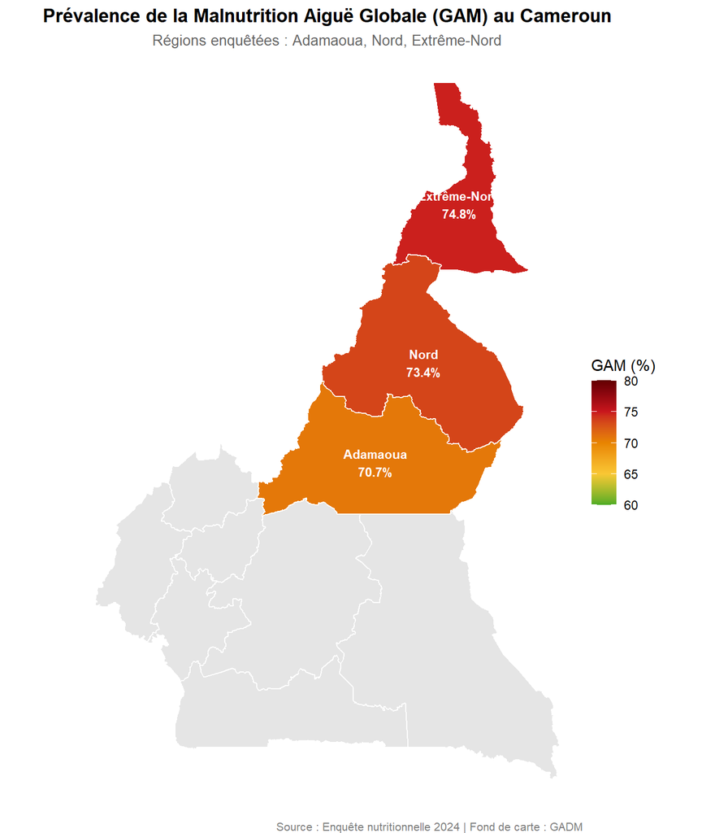

Prévalence de la GAM par région. Les régions en gris n’ont pas été enquêtées.

```r
# Centroïdes pour placer les étiquettes au centre de chaque région
centroides <- carte_sf |>
  filter(!is.na(GAM_pct)) |>
  st_centroid() |>
  mutate(
    lon = st_coordinates(geometry)[, 1],
    lat = st_coordinates(geometry)[, 2]
  ) |>
  st_drop_geometry()

ggplot(carte_sf) +
  # Couche 1 : fond gris — TOUTES les régions du Cameroun
  geom_sf(fill = "grey90", color = "white", linewidth = 0.4) +
  # Couche 2 : régions enquêtées, colorées selon le taux de GAM
  geom_sf(
    data  = filter(carte_sf, !is.na(GAM_pct)),
    aes(fill = GAM_pct),
    color = "white", linewidth = 0.5
  ) +
  # Couche 3 : étiquettes (nom région + valeur GAM)
  geom_text(
    data = centroides,
    aes(x = lon, y = lat,
        label = paste0(region, "\n", round(GAM_pct, 1), "%")),
    size = 3, fontface = "bold", color = "white"
  ) +
  # Palette OMS : vert (acceptable) → jaune → orange → rouge → rouge foncé (urgence)
  scale_fill_gradientn(
    colors   = pal_gam,
    na.value = "grey90",
    name     = "GAM (%)",
    limits   = c(60, 80)
  ) +
  labs(
    title    = "Prévalence de la Malnutrition Aiguë Globale (GAM) au Cameroun",
    subtitle = "Régions enquêtées : Adamaoua, Nord, Extrême-Nord",
    caption  = "Source : Enquête nutritionnelle 2024 | Fond de carte : GADM"
  ) +
  theme_void() +
  theme(
    plot.title      = element_text(hjust = 0.5, face = "bold", size = 13),
    plot.subtitle   = element_text(hjust = 0.5, color = "grey40", size = 10),
    plot.caption    = element_text(hjust = 1,   color = "grey50", size = 8),
    legend.position = "right"
  )
```

### 5.3 Carte choroplèthe + points GPS individuels

En superposant les coordonnées GPS de chaque ménage, on visualise simultanément la **prévalence régionale** (fond coloré) et la **répartition spatiale des cas individuels** (points).

```r
# Convertir les coordonnées GPS en objet sf (système WGS84)
points_enquete <- df_map |>
  filter(!is.na(gps_latitude), !is.na(gps_longitude)) |>
  st_as_sf(coords = c("gps_longitude", "gps_latitude"), crs = 4326)
```

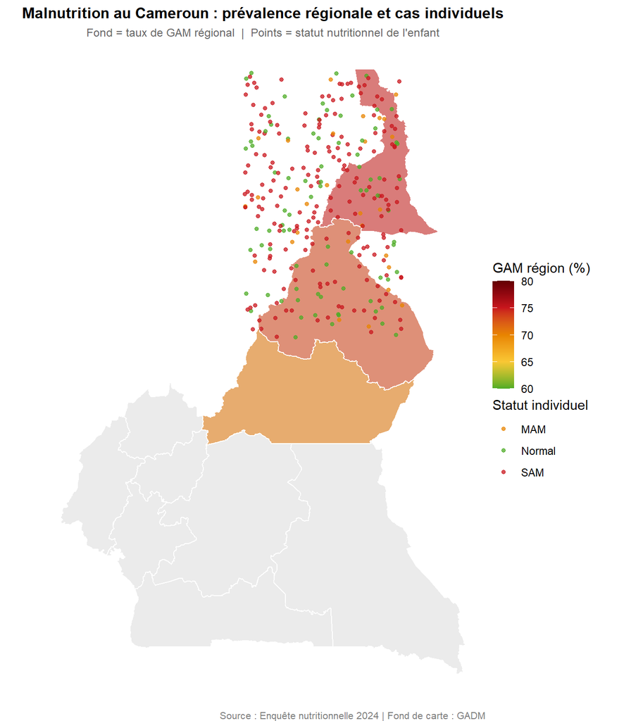

Carte combinée : choroplèthe régionale + statut nutritionnel individuel.

```r
ggplot() +
  # Couche 1 : fond — toutes les régions
  geom_sf(data = carte_sf, fill = "grey92", color = "white", linewidth = 0.4) +
  # Couche 2 : régions enquêtées (semi-transparentes pour voir les points dessous)
  geom_sf(
    data  = filter(carte_sf, !is.na(GAM_pct)),
    aes(fill = GAM_pct),
    color = "white", linewidth = 0.5, alpha = 0.55
  ) +
  # Couche 3 : un point par ménage, coloré selon le statut nutritionnel
  geom_sf(
    data  = points_enquete,
    aes(color = nutr_cat),
    size  = 1.2, alpha = 0.75
  ) +
  # Choroplèthe : palette OMS pour la GAM
  scale_fill_gradientn(
    colors   = pal_gam,
    na.value = "grey92",
    name     = "GAM région (%)",
    limits   = c(60, 80)
  ) +
  # Points : couleurs OMS par statut nutritionnel
  scale_color_manual(
    values = couleurs_statut,
    name   = "Statut individuel"
  ) +
  labs(
    title    = "Malnutrition au Cameroun : prévalence régionale et cas individuels",
    subtitle = "Fond = taux de GAM régional  |  Points = statut nutritionnel de l'enfant",
    caption  = "Source : Enquête nutritionnelle 2024 | Fond de carte : GADM"
  ) +
  theme_void() +
  theme(
    plot.title      = element_text(hjust = 0.5, face = "bold", size = 12),
    plot.subtitle   = element_text(hjust = 0.5, color = "grey40", size = 9),
    plot.caption    = element_text(hjust = 1,   color = "grey50", size = 8),
    legend.position = "right"
  )
```

## 6 Cartes interactives avec plotly

### 6.1 Méthode simple : `ggplotly()`

La fonction `ggplotly()` **convertit automatiquement** une carte ggplot2 en carte interactive plotly. C’est la méthode la plus rapide car elle réutilise le code ggplot2 existant.

**Astuce clé** : ajouter l’esthétique `text` dans `aes()` et préciser `tooltip = "text"` dans `ggplotly()` pour personnaliser les infobulles.

```r
carte_pour_plotly <- ggplot(carte_sf) +
  geom_sf(fill = "grey90", color = "white", linewidth = 0.4) +
  geom_sf(
    data = filter(carte_sf, !is.na(GAM_pct)),
    aes(
      fill = GAM_pct,
      # L'esthétique "text" sera lue par plotly pour construire les infobulles
      text = paste0(
        "Région : ", region,                           "\n",
        "GAM    : ", round(GAM_pct,      1), "%\n",
        "SAM    : ", round(SAM_pct,      1), "%\n",
        "MAM    : ", round(MAM_pct,      1), "%\n",
        "Retard croissance : ", round(Stunting_pct, 1), "%\n",
        "Enfants enquêtés : ", n_enfants
      )
    ),
    color = "white", linewidth = 0.5
  ) +
  scale_fill_gradientn(
    colors   = pal_gam,
    na.value = "grey90",
    name     = "GAM (%)",
    limits   = c(60, 80)
  ) +
  labs(title = "Prévalence GAM au Cameroun — survolez une région pour les détails") +
  theme_void() +
  theme(plot.title = element_text(hjust = 0.5, face = "bold", size = 11))

# tooltip = "text" active notre infobulle personnalisée
ggplotly(carte_pour_plotly, tooltip = "text")
```

[interactive chart not shown]

**NoteAvantages et limites de `ggplotly()`**

|  | Avantages | Limites |
| --- | --- | --- |
| ✅ | Code très court, réutilise ggplot2 | Infobulles HTML limitées (pas de gras) |
| ✅ | Fidèle à l’apparence ggplot2 | Moins de contrôle sur les interactions |
| ✅ | Idéal pour des rapports rapides | Peut être lent avec beaucoup de points |

### 6.2 Méthode avancée : `plot_ly()` natif

La méthode native `plot_ly()` offre **plus de contrôle** sur l’apparence et les interactions. On utilise `add_sf()` pour les polygones et `add_trace()` pour les points GPS.

```r
points_df_plotly <- df_map |>
  filter(!is.na(gps_latitude), !is.na(gps_longitude)) |>
  mutate(
    info = paste0(
      "Village  : ", village,              "\n",
      "District : ", district,             "\n",
      "Région   : ", region,               "\n",
      "Statut   : ", nutr_cat,             "\n",
      "WHZ      : ", round(whz_score, 2),  "\n",
      "MUAC     : ", muac_mm,              " mm"
    )
  )

plot_ly() |>
  # Couche 1 : fond gris — toutes les régions du Cameroun
  add_sf(
    data      = cameroun_sf,
    color     = I("grey85"),
    line      = list(color = "white", width = 1),
    name      = "Cameroun",
    hoverinfo = "none"
  ) |>
  # Couche 2 : régions enquêtées colorées selon le taux de GAM (palette OMS)
  add_sf(
    data          = filter(carte_sf, !is.na(GAM_pct)),
    color         = ~GAM_pct,
    colors        = pal_gam,
    text          = ~paste0(
      "<b>", region, "</b><br>",
      "GAM : ", round(GAM_pct,      1), "%<br>",
      "SAM : ", round(SAM_pct,      1), "%<br>",
      "MAM : ", round(MAM_pct,      1), "%<br>",
      "Retard croissance : ", round(Stunting_pct, 1), "%<br>",
      "Enfants enquêtés : ", n_enfants
    ),
    hovertemplate = "%{text}<extra></extra>",
    showlegend    = FALSE
  ) |>
  # Couche 3 : points GPS des ménages (couleurs OMS par statut)
  add_trace(
    data          = points_df_plotly,
    type          = "scatter",
    mode          = "markers",
    x             = ~gps_longitude,
    y             = ~gps_latitude,
    color         = ~nutr_cat,
    colors        = couleurs_statut,
    marker        = list(size = 5, opacity = 0.75),
    text          = ~info,
    hovertemplate = "%{text}<extra></extra>",
    name          = ~nutr_cat
  ) |>
  layout(
    title  = list(
      text = "<b>Malnutrition au Cameroun — carte interactive complète</b>",
      x    = 0.5
    ),
    xaxis  = list(title = "", showgrid = FALSE, zeroline = FALSE),
    yaxis  = list(title = "", showgrid = FALSE, zeroline = FALSE),
    legend = list(title = list(text = "<b>Statut nutritionnel</b>")),
    margin = list(l = 0, r = 0, t = 50, b = 0)
  )
```

[interactive chart not shown]

## 7 Comparaison des indicateurs par onglets

Cette section permet de **comparer visuellement** les quatre indicateurs de malnutrition. En HTML, cliquez sur les onglets. En PDF et Word, les indicateurs s’affichent à la suite sous forme de sous-sections.

**NoteComment fonctionne un tabset en Quarto ?**

Un tabset se crée avec `::: {.panel-tabset}` et se ferme avec `:::`. Chaque titre `###` à l’intérieur devient un onglet cliquable en HTML. En PDF/Word, les onglets deviennent des sous-sections séquentielles.

```
::: {.panel-tabset}

### Nom de l'onglet 1
Contenu de l'onglet 1

### Nom de l'onglet 2
Contenu de l'onglet 2

:::
```

```r
# Fonction réutilisable : évite de répéter le même code pour chaque indicateur.
# Paramètres :
#   col_pct     : nom de la colonne (ex. "GAM_pct")
#   titre       : titre de la carte
#   nom_legende : label de la légende
#   limites     : vecteur c(min, max) de l'échelle
#   couleurs    : palette OMS propre à l'indicateur

carte_indicateur <- function(col_pct, titre, nom_legende, limites, couleurs) {

  valeurs <- carte_sf[[col_pct]]

  carte_sf_temp <- carte_sf |>
    mutate(
      valeur    = valeurs,
      infobulle = paste0(
        "Région : ",    region,                          "\n",
        nom_legende, " : ", round(valeur, 1),            "%\n",
        "Enfants enquêtés : ", ifelse(is.na(n_enfants), "—", n_enfants)
      )
    )

  p <- ggplot(carte_sf_temp) +
    geom_sf(fill = "grey90", color = "white", linewidth = 0.4) +
    geom_sf(
      data  = filter(carte_sf_temp, !is.na(valeur)),
      aes(fill = valeur, text = infobulle),
      color = "white", linewidth = 0.5
    ) +
    # scale_fill_gradientn() accepte plus de 2 couleurs → idéal pour la palette OMS
    scale_fill_gradientn(
      colors   = couleurs,
      na.value = "grey90",
      name     = nom_legende,
      limits   = limites
    ) +
    labs(title = titre) +
    theme_void() +
    theme(plot.title = element_text(hjust = 0.5, face = "bold", size = 11))

  # En HTML  → carte interactive plotly avec infobulles
  # En PDF/Word → carte statique ggplot2 (plotly ne fonctionne pas hors HTML)
  if (knitr::is_html_output()) {
    ggplotly(p, tooltip = "text")
  } else {
    p
  }
}
```

**GAM — Malnutrition aiguë globale**

La **GAM** (Global Acute Malnutrition) regroupe tous les enfants avec un score WHZ < −2 ou présentant des œdèmes. C’est l’indicateur de référence pour évaluer la situation nutritionnelle d’urgence.

```r
carte_indicateur(
  col_pct     = "GAM_pct",
  titre       = "Prévalence de la GAM au Cameroun (%)",
  nom_legende = "GAM (%)",
  limites     = c(60, 80),
  couleurs    = pal_gam
)
```

[interactive chart not shown]

**SAM — Malnutrition sévère**

La **SAM** (Severe Acute Malnutrition) concerne les enfants avec un score WHZ < −3 ou un MUAC < 115 mm. Ces cas nécessitent une prise en charge thérapeutique urgente.

```r
carte_indicateur(
  col_pct     = "SAM_pct",
  titre       = "Prévalence de la SAM au Cameroun (%)",
  nom_legende = "SAM (%)",
  limites     = c(55, 70),
  couleurs    = pal_sam
)
```

[interactive chart not shown]

**MAM — Malnutrition modérée**

La **MAM** (Moderate Acute Malnutrition) désigne les enfants avec −3 ≤ WHZ < −2. Ils bénéficient de programmes d’alimentation supplémentaire (PASAM).

```r
carte_indicateur(
  col_pct     = "MAM_pct",
  titre       = "Prévalence de la MAM au Cameroun (%)",
  nom_legende = "MAM (%)",
  limites     = c(0, 20),
  couleurs    = pal_mam
)
```

[interactive chart not shown]

**Stunting — Retard de croissance**

Le **retard de croissance** (Stunting) correspond à un score HAZ < −2. Il reflète une malnutrition chronique avec des effets durables sur le développement cognitif et physique de l’enfant.

```r
carte_indicateur(
  col_pct     = "Stunting_pct",
  titre       = "Prévalence du retard de croissance (Stunting) au Cameroun (%)",
  nom_legende = "Stunting (%)",
  limites     = c(10, 80),
  couleurs    = pal_stunting
)
```

[interactive chart not shown]

**Tous les indicateurs**

Ce tableau récapitule l’ensemble des prévalences par région enquêtée. Il permet une **lecture comparative rapide** de tous les indicateurs côte à côte.

```r
tableau_recap <- donnees_region |>
  mutate(across(ends_with("_pct"), \(x) paste0(round(x, 1), " %"))) |>
  rename(
    "Région"                   = region,
    "Enfants enquêtés"         = n_enfants,
    "GAM (%)"                  = GAM_pct,
    "SAM (%)"                  = SAM_pct,
    "MAM (%)"                  = MAM_pct,
    "Retard de croissance (%)" = Stunting_pct
  )

kable(
  tableau_recap,
  align   = c("l", "c", "c", "c", "c", "c"),
  caption = "Tableau récapitulatif des prévalences de malnutrition par région (Enquête 2024)"
)
```

Tableau récapitulatif des prévalences de malnutrition par région (Enquête 2024)

| Région | Enfants enquêtés | GAM (%) | SAM (%) | MAM (%) | Retard de croissance (%) |
| --- | --- | --- | --- | --- | --- |
| Adamaoua | 99 | 70.7 % | 61.6 % | 9.1 % | 40.4 % |
| Extrême-Nord | 107 | 74.8 % | 65.4 % | 9.3 % | 37.4 % |
| Nord | 94 | 73.4 % | 63.8 % | 9.6 % | 37.2 % |

**NoteLecture du tableau**

- **GAM** = SAM + MAM (malnutrition aiguë globale)
- **SAM** : cas sévères nécessitant une prise en charge thérapeutique urgente
- **MAM** : cas modérés relevant des programmes d’alimentation supplémentaire
- **Retard de croissance** : malnutrition chronique (indicateur HAZ)

## 8 Résumé des fonctions clés

Voici un tableau de référence rapide des fonctions utilisées dans ce document.

| Fonction | Package | Rôle |
| --- | --- | --- |
| `st_read(url)` | `sf` | Lire un shapefile ou GeoJSON (local ou en ligne) |
| `st_as_sf(coords = ...)` | `sf` | Convertir un tableau de coordonnées GPS en objet sf |
| `st_centroid()` | `sf` | Calculer le point central d’un polygone |
| `st_drop_geometry()` | `sf` | Retirer la colonne géométrie pour obtenir un data frame |
| `left_join()` | `dplyr` | Joindre les données au shapefile par une colonne commune |
| `geom_sf()` | `ggplot2` | Dessiner des polygones ou points sf dans ggplot2 |
| `aes(fill = variable)` | `ggplot2` | Colorier les polygones selon une variable |
| `scale_fill_gradientn()` | `ggplot2` | Dégradé OMS multi-couleurs (plus de 2 couleurs) |
| `theme_void()` | `ggplot2` | Supprimer axes et quadrillage (style carte) |
| `ggplotly(carte, tooltip = "text")` | `plotly` | Convertir une carte ggplot2 en carte plotly interactive |
| `add_sf()` | `plotly` | Ajouter des polygones sf à une figure plotly |
| `add_trace()` | `plotly` | Ajouter des points (scatter) à une figure plotly |
| `knitr::is_html_output()` | `knitr` | Détecter le format de sortie (HTML vs PDF/Word) |